# Lecture 7. Black Scholes Options Pricing

# Purpose

- Develop European-style option valuation formula
  - The Black-Scholes formula is a limiting case of the binomial formula(infinitely many periods) for the price of a European option.
  - Called “Black-Scholes” or “Black-Scholes/Merton” model
- Key ideas are
  - Risk-free hedge and risk neutral valuation
  - Log-normal asset price distribution mechanics
  - BSM option valuation formula and its variants

# Black-Scholes Assumptions

- Assumptions about stock return distribution
  - Continuously compounded returns on the stock are normally distributed and independent over time, i.e. stock prices are log-normally distributed.
  - The volatility of continuously compounded returns is known and constant
  - Future dividends are known, either as dollar amount or as a fixed dividend yield
- Assumptions about the economic environment
  - The risk-free rate is known and constant
  - There are no transaction costs or taxes
  - It is possible to short-sell costlessly and to borrow at the risk-free rate

# Black-Scholes Model

- Under risk-neutrality, current call value is
  $$c = e^{-rT}\mathbb{E}[\tilde c_T]$$
- $\mathbb{E}[\tilde c_T]$ is the expected terminal call price based on asset price distribution
- Terminal call value is

$$\tilde c_T =
\left\{
\begin{aligned}
& \tilde{S}_T - K, & if \quad \tilde{S}_T\ge K \\
& 0, & if \quad \tilde{S}_T \le K
\end{aligned}
\right.$$

- Expected terminal call value of exercise price $K$ is

$$\begin{equation}
\begin{split}
\mathbb{E}[\tilde C_T] &= \mathbb{E}[\widetilde S_T - K \mid S_T > K] \cdot Pr(S_T > K)\\
& =\mathbb{E}[\tilde S_T \mid S_T > K] \cdot Pr(S_T > K) - \mathbb{E}[K \mid S_T > K] \cdot Pr(S_T > K)\\
& =\mathbb{E}[\tilde S_T \mid S_T > K] \cdot Pr(S_T > K) - K \cdot Pr(S_T > K)
\end{split}
\end{equation}$$

- Note that the result does not depend on asset price distribution

# Expected value for Call option

- Under lognormality, expected value is

$$E[\tilde{C}_T] = Se^{(\alpha - \delta)T}N(d_1) - KN(d_2)$$

- where

$$\begin{equation}
\begin{split}
d_1 &= \frac{ln(\frac{S}{K}) + (\alpha - \delta + \frac{1}{2}\sigma^2)T}{\sigma \sqrt{T}}\\
d_2 &= d_1 - \sigma \sqrt{T}
\end{split}
\end{equation}$$

# Standard Normal Distribution $N(d)$

- Use $z$ to represent a random variable that has a standard normal distribution

$$\mathbb{E}[\tilde Z] = 0 \text{ and } Var(\widetilde Z) = 1$$

- The value of the cumulative normal distribution $N(d)$ equals to the probability $P(z < d)$ of a number $z$ drawn from the normal distribution to be less than $d$

$$N(d) = \int _{-\infty}^{d} \frac{1}{\sqrt{2 \pi}} e^{-\frac{1}{2}x^2}dx$$

- $N(- \infty) = 0$ and $N(\infty) = 1$
- Normal density is symmetric

$$N(-d) = 1 - N(d)$$

- $N(d)$ is cumulative normal probability. Area under curve to left of $d$
- In Excel, use **“=NORMSDIST(d)”**

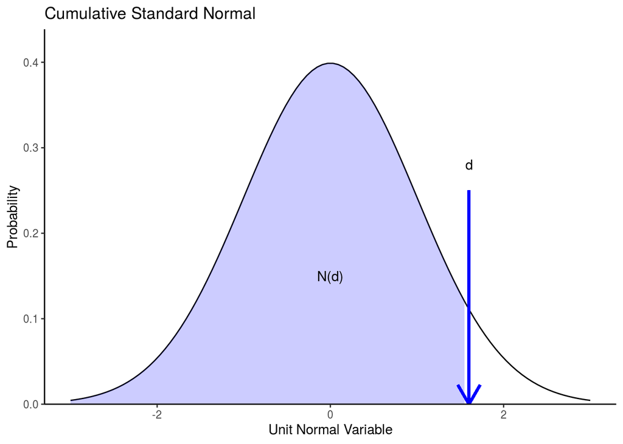

Cumulative Standard Normal

## Call option price

- Take present value of expected future value to get European-style call formula

$$c = e^{-rT}\mathbb{E}[\tilde{c}_T]$$

- Thus,

$$c = Se^{(-r + \alpha - \delta)T}N(d_1) - Ke^{-rT}N(d_2)$$

- where

$$\begin{equation}
\begin{split}
d_1 & = \frac{ln(\frac{S}{K}) + (\alpha - \delta + \frac{1}{2}\sigma^2)T}{\sigma \sqrt{T}} \\
d_2 & = d_1 - \sigma \sqrt{T}
\end{split}
\end{equation}$$

- Black and Scholes(1973) value call on non-dividend paying stock
- Set $\alpha = r$ and $\delta = 0$

$$c = SN(d_1) - Ke^{-rT}N(d_2)$$

## Futures option valuation

- Black (1975) values call on futures
- Set $\alpha = 0$ and $\delta = 0$

$$c = e^{−rT}[F N(d_1) − KN(d_2)]$$

- where

$$\begin{equation}
\begin{split}
d_1 & = \frac{ln(\frac{F}{K}) + \frac{1}{2}\sigma^2T}{\sigma \sqrt{T}} \\
d_2 & = d_1 - \sigma \sqrt{T}
\end{split}
\end{equation}$$

## Stock index option valuation

- Merton(1973) values call on index
- Set $\alpha = r$

$$c = Se^{-\delta T}N(d_1) - Ke^{-rT}N(d_2)$$

- where

$$\begin{equation}
\begin{split}
d_1 & = \frac{ln(\frac{S}{K}) + (r - \delta + \frac{1}{2}\sigma^2)T}{\sigma \sqrt{T}} \\
d_2 & = d_1 - \sigma \sqrt{T}
\end{split}
\end{equation}$$

## Currency option valuation

- Garman and Kohlhagen(1983) value call on foreign currency
- Set $\alpha = r_d$ and $\delta = r_f$

$$c = Se^{-r_f T}N(d_1) - Ke^{-r_dT}N(d_2)$$

- where

$$\begin{equation}
\begin{split}
d_1 & = \frac{ln(\frac{S}{K}) + (r_d - r_f + \frac{1}{2}\sigma^2)T}{\sigma \sqrt{T}} \\
d_2 & = d_1 - \sigma \sqrt{T}
\end{split}
\end{equation}$$

# Black-Scholes/Merton(BSM) Model

- BSM value of European-style call is

$$c = Se^{-\delta T}N(d_1) - Ke^{-rT}N(d_2)$$

- where

$$\begin{equation}
\begin{split}
d_1 & = \frac{ln(\frac{S}{K}) + (r - \delta + \frac{1}{2}\sigma^2)T}{\sigma \sqrt{T}} \\
d_2 & = d_1 - \sigma \sqrt{T}
\end{split}
\end{equation}$$

- Re-arrange expression for upper integral limit

$$\begin{equation}
\begin{split}
d_1 & = \frac{ln(\frac{S}{K}) + (r - \delta + \frac{1}{2}\sigma^2)T}{\sigma \sqrt{T}}\\
& = \frac{ln(\frac{Se^{-\delta T}}{Ke^{-rT}})+ \frac{1}{2}\sigma ^2 T}{\sigma \sqrt{T}}
\end{split}
\end{equation}$$

- European-style put formula follows directly from
  - Put-call parity
  - European-style call formula

$$\begin{equation}
\begin{split}
p & = Ke^{-rT} - Se^{-\delta T} + C \\
& = Ke^{-rT} -Se^{-\delta T} + Se^{-\delta T}N(d_1) - Ke^{-rT}N(d_2) \\
& = Ke^{-rT}[1-N(d_2)] -Se^{-\delta T}[1-N(d_1)] \\
& = Ke^{-rT}N(-d_2) - S^{-\delta T}N(-d_1)
\end{split}
\end{equation}$$

- BSM value of European-style put is

$$P = Ke^{-rT}N(-d_2) - S^{-\delta T}N(-d_1)$$

- where

$$\begin{equation}
\begin{split}
d_1 & = \frac{ln(\frac{Se^{-\delta T}}{Ke^{-rT}}) + \frac{1}{2}\sigma ^2 T}{\sigma \sqrt{T}} \\
d_2 &= d_1 - \sigma \sqrt{T}
\end{split}
\end{equation}$$

## Illustration

- Value call and put options with $K = 40$ and $T = 3$ months
- Assume stock price is 41.00, stock pays no dividends, and stock’s volatility rate is 30% annually
- Assume interest rate is 8 % annually
- Download excel file
  - [Black Scholes Merton Option Pricing.xlsx](https://github.com/hyunyulhenry/bae_derivatives/raw/master/Excel/07%20Black%20Scholes%20Merton%20Option%20Pricing.xlsx)
  - Sheet : Option Valuation
- $Se^{-\delta T} \ and \ Ke^{-rT}$
  $$Se^{-\delta T} = Se^{-0(3/12)} = 41$$
  $$Ke^{-rT} = Ke^{-0.08(3/12)} = 39.21$$
- $N(d_1) \ and \ N(d2)$

$$\begin{equation}
\begin{split}
d_1 & = \frac{ln(\frac{41}{39.21}) + 0.5(0.3^2)(0.25)}{0.3 \sqrt{0.25}} = 0.373 \\
d_2 & = 0.373 - 0.3 \sqrt{0.25} = 0.223
\end{split}
\end{equation}$$

$$N(d_1) = N(0.373) = 0.6454$$
$$N(d_2) = N(0.223) = 0.5882$$

- Call option price

$$\begin{equation}
\begin{split}
C & = SN(d_1) - Ke^{-rT}N(d_2) \\
& = 41(0.6454) - 39.21(0.5882) \\
& = 3.399
\end{split}
\end{equation}$$

- Put option price

$$\begin{equation}
\begin{split}
P & = Ke^{-rT}N(-d_2) - SN(-d_1) \\
& = 39.21(1 - 0.5882) - 41(1 - 0.6454) \\
& = 1.607
\end{split}
\end{equation}$$

## Applying the model

- To use BSM formula to value options, we need estimates of
  - asset price : $S$
  - exercise price : $K$
  - time to expiration : $T$
  - income rate : $\delta$
  - interest rate : $r$
  - volatility : $\sigma$
- Some parameters are terms of option contracts
  - exercise price : $K$
  - time to expiration : $T$
- Some parameters are easily accessible market prices
  - asset price : $S$ $\rightarrow$ Use current bid/ask midpoint or last traded price
  - income rate : $\delta$ $\rightarrow$ Use dividend yield rate, foreign interest rate, lease rate etc
  - interest rate : $r$ $\rightarrow$ Use continuously compounded T-bill rate
- One parameter is more troublesome to estimate than others
  - volatility : $\sigma$
- Estimating volatility
  - Historical volatility
  - Implied volatility

# Volatility

- Volatility is unobservable
- Option prices can be quite sensitive to volatility
- One approach is to compute **historical volatility**: One problem with historical volatility is that expected future volatility can be different from historical volatility
- Alternatively, we can calculate **implied volatility**, which is the volatility that, when put into BSM formula, yields the observed option price

## Historical Volatility

- The logarithmic function computes daily returns from daily prices
  $$r_{t+1} = ln(S_{t+1} / S_t)$$
- Since returns are additive, annual return is
  $$r_{annual} = \sum_{t=1}^{252}r_t = \sum_{t=1}^{252}ln(S_t / S_{t-1}) = ln(S_{252} / S_0)$$
- The variance of the annual return is
  $$Var(r_{annual}) = Var(\sum_{t=1}^{252}r_t)$$
- Suppose that returns are uncorrelated over time and that each day has the same variance of returns
  $$Var(r_{annual}) = 252Var(r_t)$$
- Taking the square root of both sides yields
  $$\sigma = \sqrt{252} \sigma_{daily}$$
- The term $\sqrt{252}$ should be modified depending the frequency of data
  - From monthly price data : $\sqrt{12}$
  - From weekly price data : $\sqrt{52}$
1. Take observations $S_0, S_1, \dots , S_T$ at interval of $\Delta t$ years. (e.g. for daily data $\Delta t = 1/252$)
2. Calculate the continuously compounded return in each interval as
   $$r_t = ln(S_t/S_{t−1}) \ for \ t = 1, 2, \dots , T$$
3. Calculate the standard deviation, $\hat \sigma$, of the $r_t$’s
4. The annualized historical volatility is
   $$\sigma = \frac{1}{\sqrt{\Delta t}} \hat \sigma$$
- Compute mean return from data. Use **“=AVERAGE()”**
  $$\hat \mu = \frac{1}{T} \sum_{t=1}^{T}r_t$$
- Compute standard deviation. Use **“=STDEV()”**
  $$\hat \sigma = \sqrt{\frac{1}{T-1}\sum_{t=1}^{T}(r_t - \hat \mu)^2}$$
- To annualize volatility, multiply by square root of number of calendar days(months, weeks, etc. ) in one year

### Historical Volatility-EWMA

- Computing volatility from standard deviation assumes the constant volatility through time
- Volatility appears to be changing over time
- If volatility is changing, we want to emphasize more recent observations
- One way to consider time-varying volatility is to compute an *Exponentially Weighted Moving Average(EWMA)* of the squared stock returns
- Equal weighted squared returns
  $$\hat \sigma = \sqrt{\frac{1}{T} \sum_{t=1}^{T} r_{t}^{2}}$$
- Exponentially weighted moving average volatility
  $$\hat \sigma_t = \sqrt{\sum_{i=1}^{n} \left[\frac{(1 - \lambda)\lambda^{i-1}}{\sum_{j=1}^{n}(1 - \lambda)\lambda^{j-1}} \right]r_{t-i}^{2}}$$
  - The lower is the value of λ, the higher is the weight placed on the most recent data
- Compute historical volatilities for AAPL
- Download five-year daily price data from http://finance.yahoo.com
- Use the **adjusted price** series which are close prices adjusted for dividends and stock-splits
  - If there are no adjusted prices, you should adjust observed closed prices for cash dividends and stock splits after getting the distribution information
- Based on adjusted close prices, compute continuously compounded returns
- Download excel file
  - [Historical Volatility.xlsx](https://github.com/hyunyulhenry/bae_derivatives/raw/master/Excel/07%20Historical%20Volatility.xlsx)
  - Sheet : Historical Volatility

Estimates depend on length of return history

| Data Length | N | StDev (Daily) | StDev (Annualized) |
| --- | --- | --- | --- |
| All Date | 1,257 | 1.69% | 26.85% |
| One year | 251 | 1.40% | 22.20% |
| 90 days | 90 | 1.26% | 20.04% |
| 30 days | 30 | 0.95% | 15.05% |

- Download excel file
  - Historical Volatility.xlsx
  - Sheet : EWMA

Volatility of Apple returns appeared to be lower later in the year

| $\lambda$ | EWMA (Daily) | EWMA (Annualized) |
| --- | --- | --- |
| 0.25 | 0.35% | 5.56% |
| 0.50 | 0.51% | 8.11% |
| 0.75 | 0.64% | 10.20% |

## Implied Volatility

- Implied volatility is computed from observed option prices
- Set option prices equal to formula value and solve for $\sigma$

$$c = f(S, K, T, r, \delta, \sigma)$$

- $c$ : observed call option price
  - $f()$: BSM formula
  - $S$ : observed stock price
  - $K$ and T : contract parameters
  - $r$ : risk-free rate
  - $\delta$ : dividend yield
- [Download AAPL option prices from CBOE website](http://www.cboe.com/DelayedQuote/QuoteTableDownload.aspx)
- Download excel file
  - [Implied Volatility.xlsx](https://github.com/hyunyulhenry/bae_derivatives/raw/master/Excel/07%20Implied%20Volatility.xlsx)
  - Sheet : IV
- Some practical uses of implied volatility include
  - Use the implied volatility from an option with an observable price to calculate the price of another option on the same underlying asset
  - Use implied volatility as a quick way to describe the level of options prices on a given underlying asset: you could quote option prices in terms of volatility, rather than as a dollar price
  - Checking the uniformity of implied volatilities across various options on the same underlying assets allows one to verify the validity of the pricing model in pricing those options

# Summary

- Use risk-neutrality and lognormal asset price distribution to value European-style options
  - Black-Scholes stock option formula
  - Black futures option formula
  - Merton constant dividend yield option formula
  - Garman/Kohlhagen currency option formula
- The contribution of Black-Scholes was not the particular formula but rather the appearance of the risk-free rate in the formula
- Applying option valuation models require estimates of
  - exercise price($K$) and time to expiration($T$)
  - underlying asset price($S$)
  - income rate ($\delta$)
  - interest rate ($r$)
  - volatility($\sigma$)
    - Historical volatility
    - Implied valatility